# Homework 4

Last complied on March 12, 2024

Zappos is testing different variations of the product page to see which one generates more sales. It has created three different versions of the product page:

Variation A: The original product page with the current design and layout. Variation B: The product page with a larger “Add to Cart” button and a different color scheme. Variation C: The product page with a video showing the shoes being worn and more detailed product information.

For the users who made a purchase, they measured the purchase amount. The data is contained in the file called “zappos.csv”.

1. Prepare the appropriate summary of the data (visual and summary statistics).

```r
library(tidyverse)
df<-read.csv("https://raw.githubusercontent.com/losiewbw/ISA633/main/zappos.csv")
df_long <- df %>% pivot_longer(everything(),
                               names_to = "treatment",
                               values_to = "spend")
df_long$treatment<- as.factor(df_long$treatment)

df_long %>% group_by(treatment) %>% summarize("mean sales" = mean(spend),
                                              "std sales" = sd(spend), "count" = n())
```

```
## # A tibble: 3 × 4
##   treatment `mean sales` `std sales` count
##   <fct>            <dbl>       <dbl> <int>
## 1 A                 45.0        14.1  3000
## 2 B                 45.8        14.2  3000
## 3 C                 48.2        14.0  3000
```

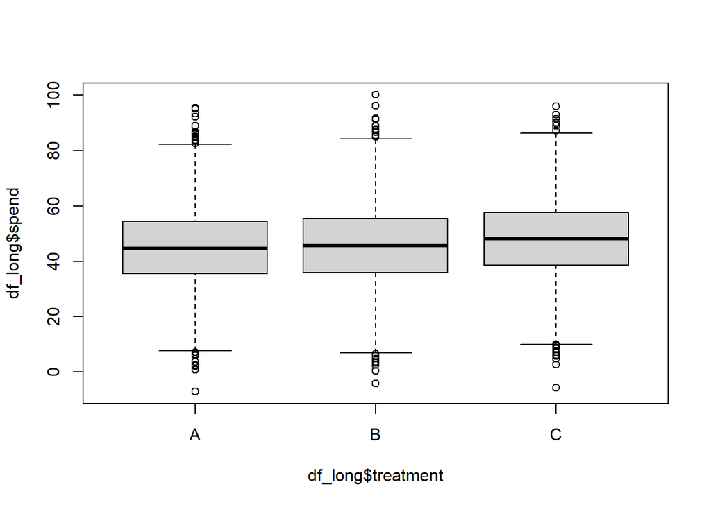

```r
boxplot(df_long$spend~df_long$treatment)
```

2. Is there evidence that the different website variations made a change? Provide that analysis below.

```r
mod<-aov(spend~treatment, data = df_long)
summary(mod)
```

```
##               Df  Sum Sq Mean Sq F value Pr(>F)
## treatment      2   16231    8115   40.75 <2e-16 ***
## Residuals   8997 1791579     199
## ---
## Signif. codes:  0 '***' 0.001 '**' 0.01 '*' 0.05 '.' 0.1 ' ' 1
```

There is evidence that the one of the different website variations made a significant change

3. Which version of the website should Zappos implement (assuming they are running A right now)?

```r
library(multcomp)
tukey<-glht(mod, linfct=mcp(treatment="Tukey"))
cld(tukey)
```

```
##   A   B   C
## "a" "a" "b"
```

```r
summary(tukey)
```

```
##
##   Simultaneous Tests for General Linear Hypotheses
##
## Multiple Comparisons of Means: Tukey Contrasts
##
##
## Fit: aov(formula = spend ~ treatment, data = df_long)
##
## Linear Hypotheses:
##            Estimate Std. Error t value Pr(>|t|)
## B - A == 0   0.7317     0.3644   2.008     0.11
## C - A == 0   3.1432     0.3644   8.627   <1e-04 ***
## C - B == 0   2.4115     0.3644   6.619   <1e-04 ***
## ---
## Signif. codes:  0 '***' 0.001 '**' 0.01 '*' 0.05 '.' 0.1 ' ' 1
## (Adjusted p values reported -- single-step method)
```

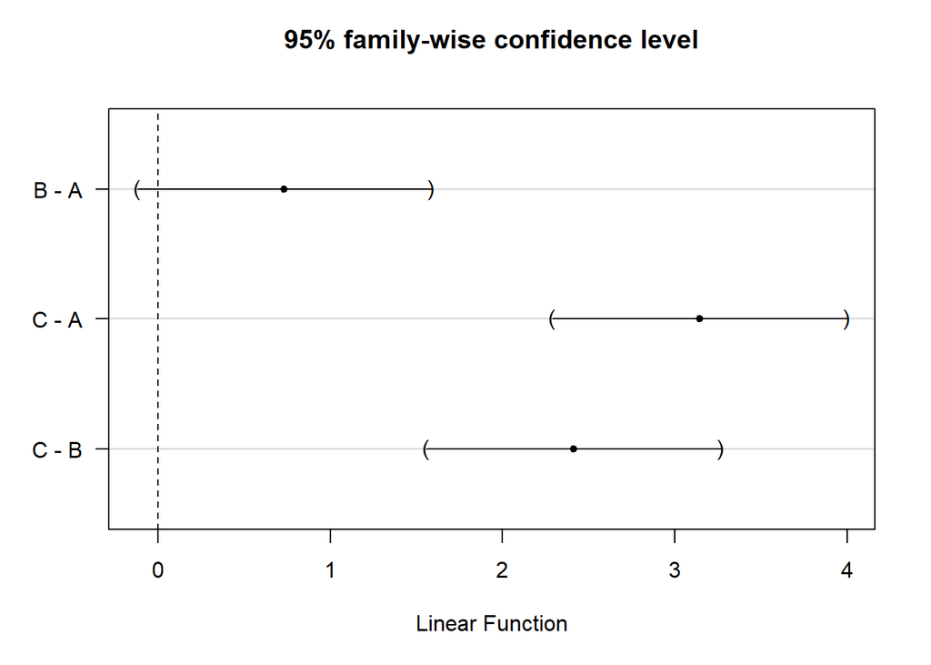

```r
plot(tukey)
```

They should be running Version C

4. Provide a sentence and recommendation as to the average spend Zappos can expect if the version you mentioned above was implemented.

```r
t.test(df$C)
```

```
##
##  One Sample t-test
##
## data:  df$C
## t = 188.59, df = 2999, p-value < 2.2e-16
## alternative hypothesis: true mean is not equal to 0
## 95 percent confidence interval:
##  47.67121 48.67290
## sample estimates:
## mean of x
##  48.17205
```

Uber conducted in the past was to test different versions of the Uber app’s home screen. In this test, users were randomly assigned to one of four groups: Group A saw the original version of the home screen, Group B saw a modified version with a larger map and a different arrangement of icons, Group C saw a modified version with personalized recommendations for their next ride and Group D saw a combination of B and C. The test was run for several weeks, and Uber monitored ride bookings. The data is contained in the file “uber.csv”.

5. Provide the appropriate summary statistics for this data.

```r
df<-read.csv("https://raw.githubusercontent.com/losiewbw/ISA633/main/uber.csv")

df_long <- df %>% pivot_longer(everything(),
                               names_to = "treatment",
                               values_to = "bookings")
df_long$treatment<- as.factor(df_long$treatment)

df_long %>% group_by(treatment, bookings) %>% summarize(n=n()) %>% mutate(freq=n/sum(n))
```

```
## # A tibble: 8 × 4
## # Groups:   treatment [4]
##   treatment bookings     n   freq
##   <fct>        <int> <int>  <dbl>
## 1 A                0  3786 0.946
## 2 A                1   214 0.0535
## 3 B                0  3842 0.960
## 4 B                1   158 0.0395
## 5 C                0  3783 0.946
## 6 C                1   217 0.0542
## 7 D                0  3744 0.936
## 8 D                1   256 0.064
```

6. Analyze the experiment

```r
full<-glm(bookings~treatment, data=df_long, family="binomial")
anova(full, test="Chisq")
```

```
## Analysis of Deviance Table
##
## Model: binomial, link: logit
##
## Response: bookings
##
## Terms added sequentially (first to last)
##
##
##           Df Deviance Resid. Df Resid. Dev  Pr(>Chi)
## NULL                      15999     6614.9
## treatment  3   25.069     15996     6589.8 1.494e-05 ***
## ---
## Signif. codes:  0 '***' 0.001 '**' 0.01 '*' 0.05 '.' 0.1 ' ' 1
```

7. What is your conclusion?

There is a significant difference between one of the treatments

8. Which version is best? Provide your recommendation.

```r
library(multcomp)
comps<-glht(full, linfct = mcp(treatment="Tukey"))
summary(comps)
```

```
##
##   Simultaneous Tests for General Linear Hypotheses
##
## Multiple Comparisons of Means: Tukey Contrasts
##
##
## Fit: glm(formula = bookings ~ treatment, family = "binomial", data = df_long)
##
## Linear Hypotheses:
##            Estimate Std. Error z value Pr(>|z|)
## B - A == 0 -0.31806    0.10734  -2.963   0.0162 *
## C - A == 0  0.01471    0.09904   0.149   0.9988
## D - A == 0  0.19036    0.09545   1.994   0.1895
## C - B == 0  0.33278    0.10704   3.109   0.0103 *
## D - B == 0  0.50842    0.10373   4.902   <0.001 ***
## D - C == 0  0.17564    0.09511   1.847   0.2508
## ---
## Signif. codes:  0 '***' 0.001 '**' 0.01 '*' 0.05 '.' 0.1 ' ' 1
## (Adjusted p values reported -- single-step method)
```

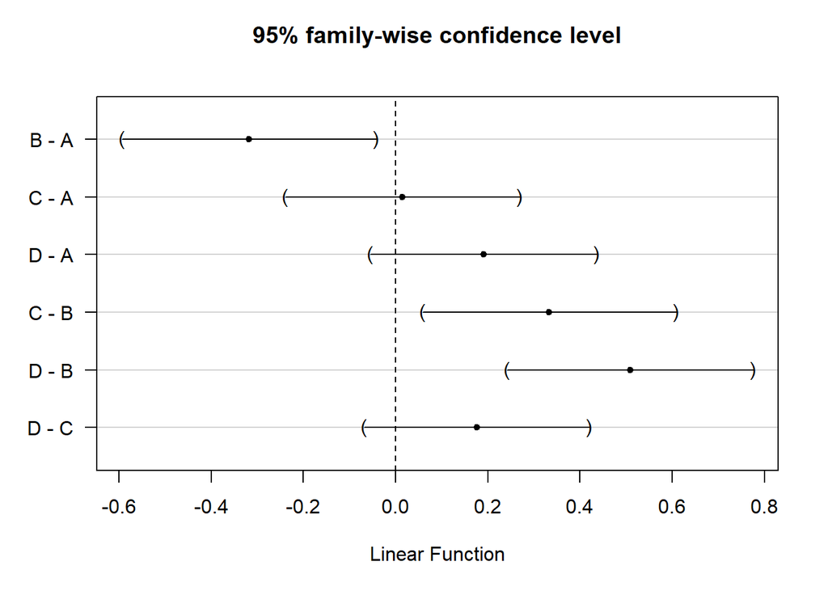

```r
plot(comps)
```

There is no clear cut recommendation. All of the versions appear to be better than B, but you would need to run further tests to find if one of the versions is absolutely better than the others.

8. If I performed 55 tests and use $\alpha=0.05$, what is the Bonferroni corrected $\alpha$ value I would use?

```r
0.05/55
```

```
## [1] 0.0009090909
```

9. Suppose you went to work for Fifth Third and they gave you some A/B testing data and asked you to use several covariates to perform a subgroup analysis. Say that they asked you to test 15 different binary variables (each category so 30 tests). What is the probability that you would make at least one type I error if your single test $\alpha=0.05$?

```r
1-(1-0.05)^30
```

```
## [1] 0.7853612
```